# EST-46114 Métodos Multivariados y Datos Categóricos Trabajo Final

Arantza Ivonne Pineda Sandoval 141194, Dante Ruíz Martínez 183340, Ana Luisa Masetto Herrera 183203

# Introducción

En este proyecto estudiamos las relaciones de dependencia que existen en el contexto de encuestas de tendencias de votos en las ultimas cuatro elecciones de Estados Unidos. Pra lograr este propóposito se utilizan tablas de contingencia y modelos de gráfos probabilísticos y pruebas de hipótesis de independencia.

En el estudio de Joshua J. Bon. et al(2018) se destaca que en la mayoría de los análisis de encuestas existen sesgos en los resultados que se originan por el tratamiento que se le da a las preferencias de los indecisos. Estos sesgos han sido más aparentes en la última elección del 2016, donde la proporción de indecisos alcanzó una magnitud tan grande que las encuestas no fueron capacez de predecir correctamente el ganador de la elección, en una competencia tan cerrada.

La siguiente gráfica que se tomó del estudio previamente mencionado, muestra el error absoluto medio de las encuestas por estado contra la media de los votantes indecidos en cada estado, se toman en consideración las elecciones del 2004, 2008, 2012 y 2016. Se puede ver que en el año 2016 donde los resultados por estado fueron muy cerrados y existía una gran proporción de votos indecisos, el error medio absoluto fue muy alto, entre 2% y 4%.

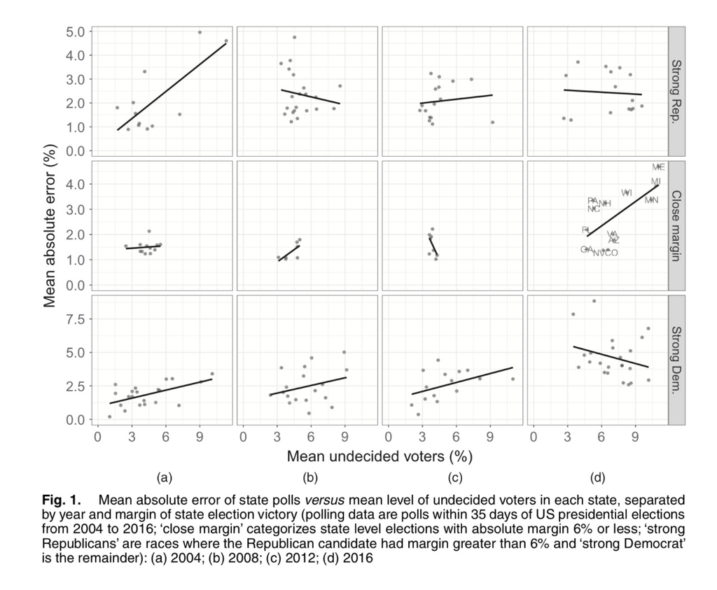

Dicho lo anterior, una característica de este proyecto es el tratamiento que se le da a las preferencias de los indecisos. En el estudio se consideran como una categoría más entre las preferencias de voto, es decir, esta variable esta compuesta de tres categorías: Demócrata, Republicano e Indeciso.

En el proyecto se utiliza la base de datos de este estudio, específicamente, la tabla de polling para estudiar las relaciones de dependencia entre las variables para contestar las siguientes dos preguntas:

1. Evaluar si la intención de voto en el polling por estado es independientemente inducida por el tiempo de duración para el día de la elección.
2. Evaluar si la casa encuestadora es independiente de los resultados de la intención de voto.

# 1. Análisis exploratorio de datos

## 1.1 Datos polling

La base de datos polling incluye la siguientes variables:

```
##  [1] "Dem_poll"               "Rep_poll"
##  [3] "Undecided"              "sample_size"
##  [5] "mean_days_to_election"  "start_days_to_election"
##  [7] "end_days_to_election"   "state"
##  [9] "year"                   "state_year"
## [11] "pollster"               "state_year_id"
## [13] "pollster2"              "year_id"
## [15] "result_margin6"         "rmargin_year"
## [17] "rmargin_year_id"        "pollster_grp"
## [19] "pollster_id"
```

La base de polling tiene 1905 observaciones y 19 variables

```
## [1] 1905   19
```

Las primeras 6 observaciones de la base de datos de polling se ve de la siguiente manera.

```
## # A tibble: 6 x 19
##   Dem_poll Rep_poll Undecided sample_size mean_days_to_el~ start_days_to_e~
##      <dbl>    <dbl>     <dbl>       <dbl>            <dbl>            <dbl>
## 1       85        7         2         310              4                  7
## 2       92        6         3         312              5.5                9
## 3       88        4         1         332             11                 14
## 4       81       13         6         310             13                 16
## 5       88        5         2         504             18                 21
## 6       29       56         5         472              4                  7
## # ... with 13 more variables: end_days_to_election <dbl>, state <chr>,
## #   year <dbl>, state_year <chr>, pollster <chr>, state_year_id <dbl>,
## #   pollster2 <chr>, year_id <dbl>, result_margin6 <chr>,
## #   rmargin_year <chr>, rmargin_year_id <dbl>, pollster_grp <chr>,
## #   pollster_id <dbl>
```

La gráfica siguiente muestra el total de valores faltantes por variable en la base de datos de polling:

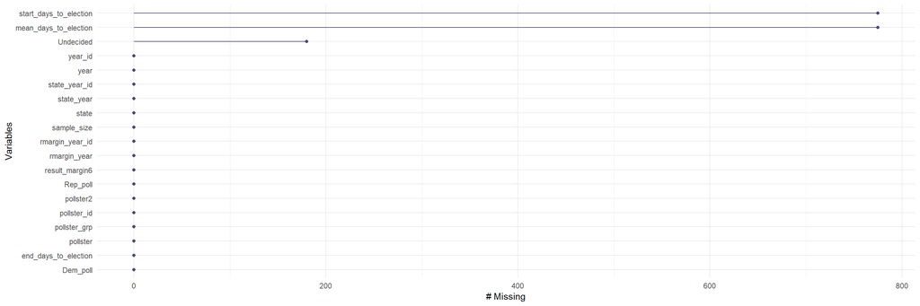

La base de datos de polling tiene NAs en las siguientes variables:

- Undecided
- mean_days_to_election
- start_days_to_election

A continuación, se presenta un breve análisis exploratorio de las variables que nos interesan para contestar las preguntas de interés.

*Año de Elección*

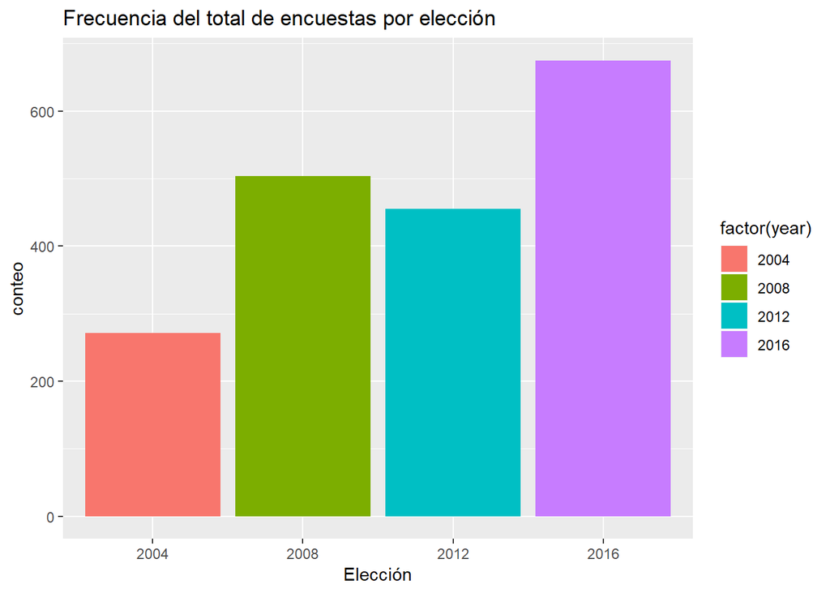

Se tienen más encuestas para la elección de 2016 y la que menos tiene es la de 2004.

*Estado*

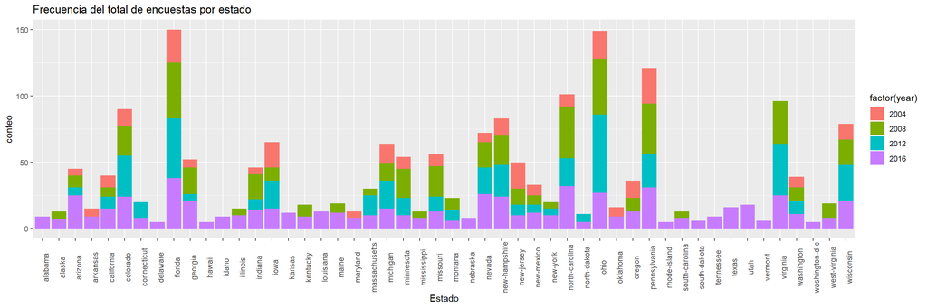

Los estados con mayor número de encuestas son: Florida, Ohio, Pensilvania, Carolina del Norte y Viginia. Así mismo se observa que no todos los estados tienen el número de encuestas.

*Casa encuestadora*

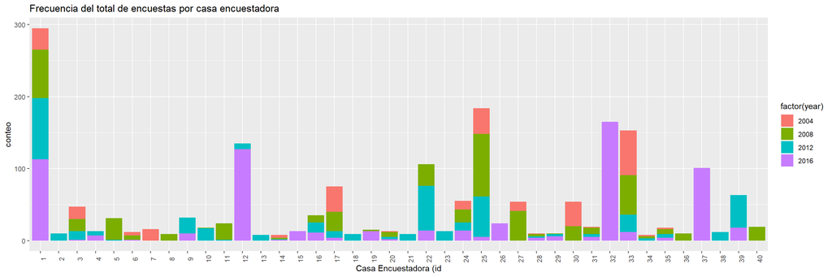

Se puede ver que la casa encuestadora con mayor número de encuestas es la primera, la cuál agrupa las casas que no tienen nombre. Se puede ver que no todas las casas encuestadoras han hecho encuestas en todas las elecciones.

A continuación, se muestra un histograma sobre el tamaño de muestra de la encuestas de tendencia del voto en la base de polling.

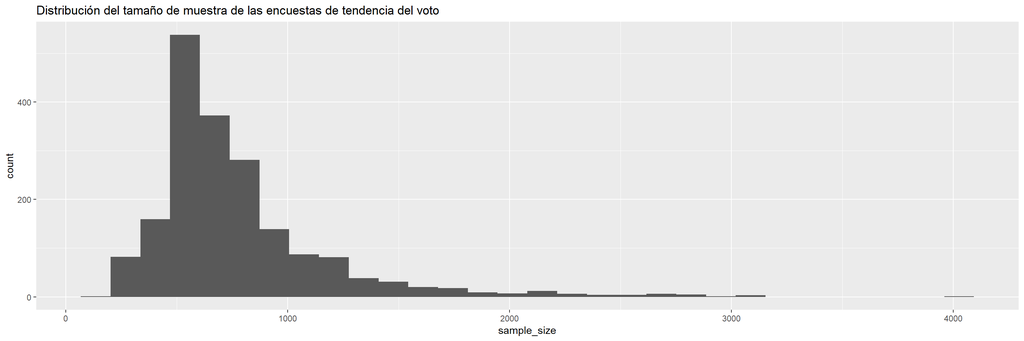

```
##   0%  25%  50%  75% 100%
##  200  545  649  869 4092
```

La base de datos muestra diferentes tamaños de muestra para cada una de las encuestas en las base de datos. El rango intercuatílico de los tamaños de muestra está entre 869 encuestas y 545. Es preciso mencionar que hay encuestas con más de 1000 encuestas.

Esta consideración es muy relevante para nuestro proyecto, dado que en el paper se menciona que diferentes tamaños de muestra en las enuestras tienen una relación con el tamaño del error de las prediccions de la intención de voto. En ese sentido es necesario reescalar todas las encuestas para que puedan ser directamente comparables.

# 2. Descripción del Método de Agregación con Justificación

## 2.1 Preprocesamiento (reescalamiento de votos)

Como se mencionó previamente, es necesario reescalar los votos para no tener sesgo por diferentes tamaños de muestra. Para reescalar se consideraron las variables Dem_poll, Rep_poll y Undecided como número de votos, dado que la suma de estos es mayor a 100 en algunos casos, por lo tanto, no pueden considerarse como proporciones, ya que ni siquiera están considerando el número de personas que no reportaron su preferencia.

```
## # A tibble: 33 x 5
##    Dem_poll Rep_poll Undecided sample_size muestra_efectiva
##       <dbl>    <dbl>     <dbl>       <dbl>            <dbl>
##  1       53       39        22         750              114
##  2       52       41         9         594              102
##  3       51       46         5         859              102
##  4       92        6         3         312              101
##  5       63       34         4         304              101
##  6       34       61         6         318              101
##  7       41       53         7         308              101
##  8       51       42         8        1331              101
##  9       51       43         7        1191              101
## 10       50       43         8         569              101
## # ... with 23 more rows
```

A continuación, se reescalan las variables utilizando un tamaño de muestra efectiva y se utilizó el 100 como tamaño base para poner todos los tamaños de la muestra en la misma escala.

Cabe mencionar que antes se intentó replicar la idea del paper de tomar en cuenta a los indecisos más personas que no compartieron sus preferencias, sin embargo, descartamos esa posibilidad dado que el número de indecisos era dominante en todos los casos, por lo tanto, los resultados obtenidos no iban a ser del todo interesantes.

## 2.2 Construir la variable de intención de voto

Dado que las tablas de contingencia trabajan con variables categóricas es necasario dar un tratamiento a las variables de número de votos para los Demócratas, Republicanos e Indecisos. Lo que haremos será mapear estás tres variables a una variable cateórica que toma el valor del partido con mayor proporción de votos al momento de la encuesta.

La variable categórica toma los siguientes valores:

- 1 si es Demócrata la proporción de votos dominante,
- 2 si es Republicano
- 3 si es Indeciso

A continuación se muestra un resumen de esta nueva variable categórica.

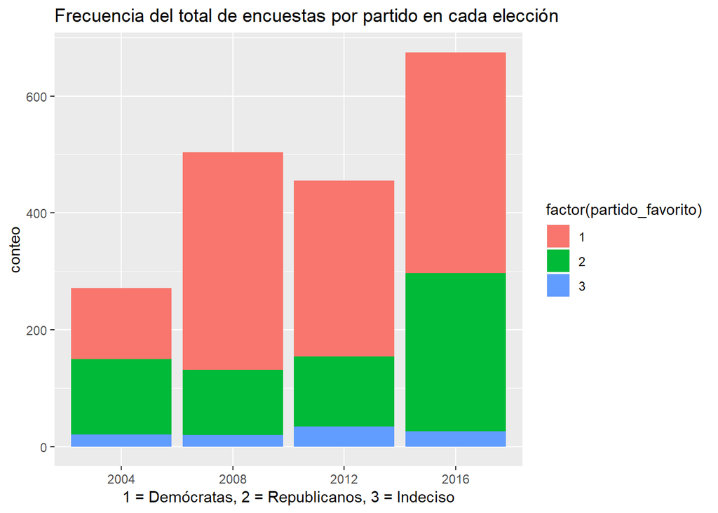

Vemos que en las encuestas predomina el partido Demócrata como ganador en casi todas las encuestas, en el 2004 predominan los republicanos.

## 2.3 Crear variable de tiempo medio antes de la elección

Asignamos una nueva variable de tiempo antes de la elección que mapea la variable de **mean_days_to_election** a una nueva variable categórica **tiempo_antes_de_la_eleccion** que está definida en bloques 5 días.

A continuación se muestra un resumen gráfico de cómo quedo esta variable.

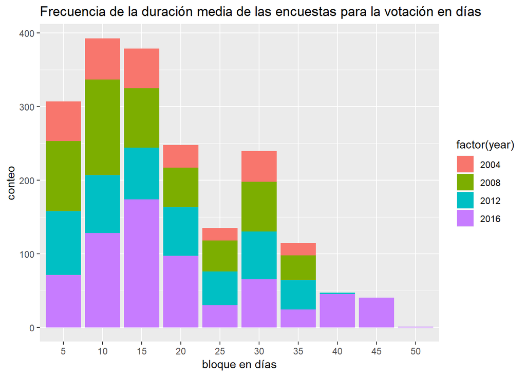

```r
base_reescalada %>% ggplot(aes(x=as.factor(tiempo_antes_de_la_eleccion),fill=factor(year))) +
  geom_bar() +
  ggtitle("Frecuencia de la duración media de las encuestas para la votación en días") +
  xlab("bloque en días") +
  ylab("conteo")
```

Vemos que la mayoría de las observaciones que tenemos son encuestas que se realizan muy próximas a los dìas de las elección 5, 10 y 15 días.

## Convertir variables en factores

Para trabajar con tablas de contingencia y las librerías para los análisis de independencia es necesario convertir las variables de interés en factores para que representen variables categóricas.

```r
base_reescalada <- base_reescalada %>%
  mutate(pollster_id = factor(pollster_id),
         partido_favorito = factor(partido_favorito),
         year_id = factor(year_id),
         tiempo_antes_de_la_eleccion = factor(tiempo_antes_de_la_eleccion),
         state=factor(as.numeric(factor(base_reescalada$state)))
         )
```

# 3. Descripción de Modelos y Relevancia para los Datos

En esta sección se presenta el procedimiento de modelación y pruebas estadísticas para cada una de las preguntas de interés.

## 3.1 Pregunta 1

**1. Evaluar si la intención de voto en el polling por estado es independientemente inducida por el tiempo de duración para el día de la elección.**

Las cuatro variables de interés para esta pregunta son partido con mayor intención de voto, estado , año de la elección y tiempo antes de la elección.

- Partido con mayor intención de voto

```
## [1] "1" "2" "3"
```

- Estado

```
##  [1] "1"  "2"  "3"  "4"  "5"  "6"  "7"  "8"  "9"  "10" "11" "12" "13" "14"
## [15] "15" "16" "17" "18" "19" "20" "21" "22" "23" "24" "25" "26" "27" "28"
## [29] "29" "30" "31" "32" "33" "34" "35" "36" "37" "38" "39" "40" "41" "42"
## [43] "43" "44" "45" "46" "47" "48" "49" "50"
```

- Tiempo antes de la elección (tiempo de duración para el día de la elección)

```
##  [1] "5"  "10" "15" "20" "25" "30" "35" "40" "45" "50"
```

- Año de elección

```
## [1] "1" "2" "3" "4"
```

Construimos la tabla de contingencia para las cuatro variables de interés, que tiene un soporte de $\chi = 3\times50\times10\times4$. La tabla de contingencia se muestra en forma de probabilidades muestrales.

La tabla de contingencia está organizada en cuatro dimensiones y es difícil mostrarla en el documento, por lo que no se incluye en la impresión.

Recuperamos la tabla de contingencias en formato de DataFrame para poder utilizar en el algoritmo y en la prueba de hipótesis:

```
##   partido_favorito state tiempo_antes_de_la_eleccion year_id freq
## 1                1     2                           4       4    1
## 2                1     3                           1       4    1
## 3                1     3                           2       4    1
## 4                1     3                           4       4    1
## 5                1     3                           5       4    1
## 6                1     3                           6       3    1
```

Cada entrada del DataFrame es una configuración del soporte.